# Stock Synthesis Recruitment Estimates

### Vermilion & Sunset Rockfish - Northern CA (2021 assessment)

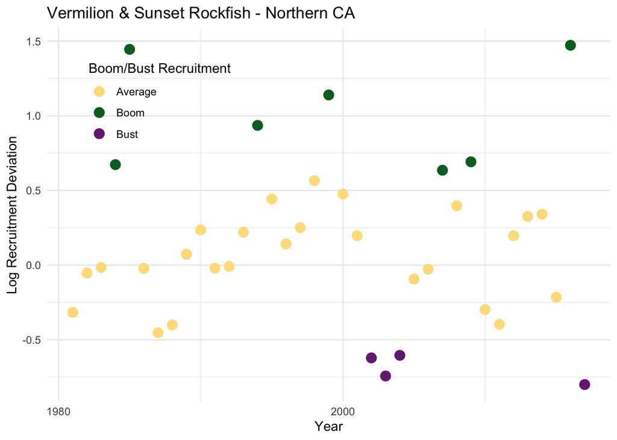

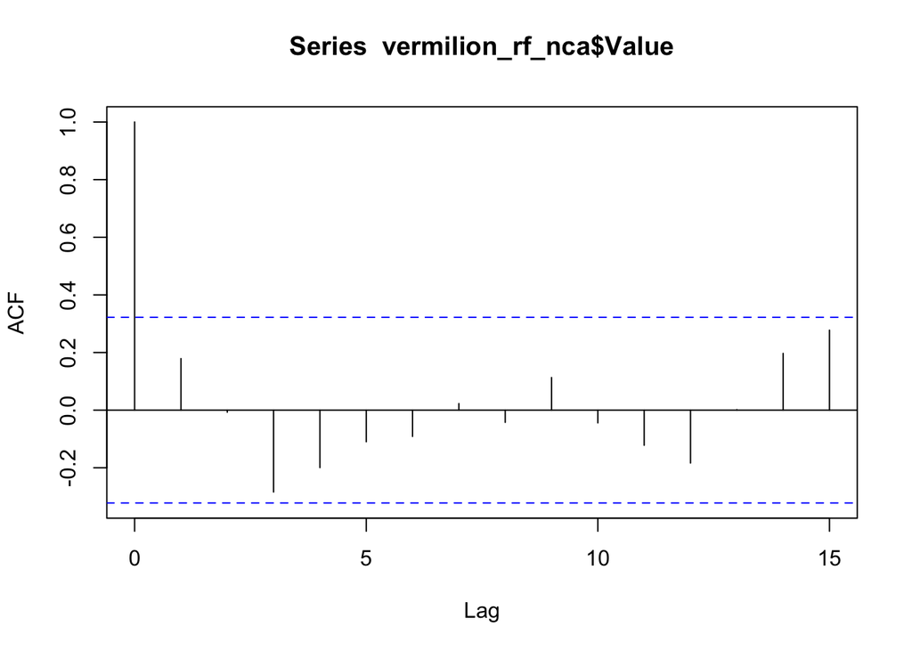

### Vermilion Rockfish - Oregon (2021 assessment)

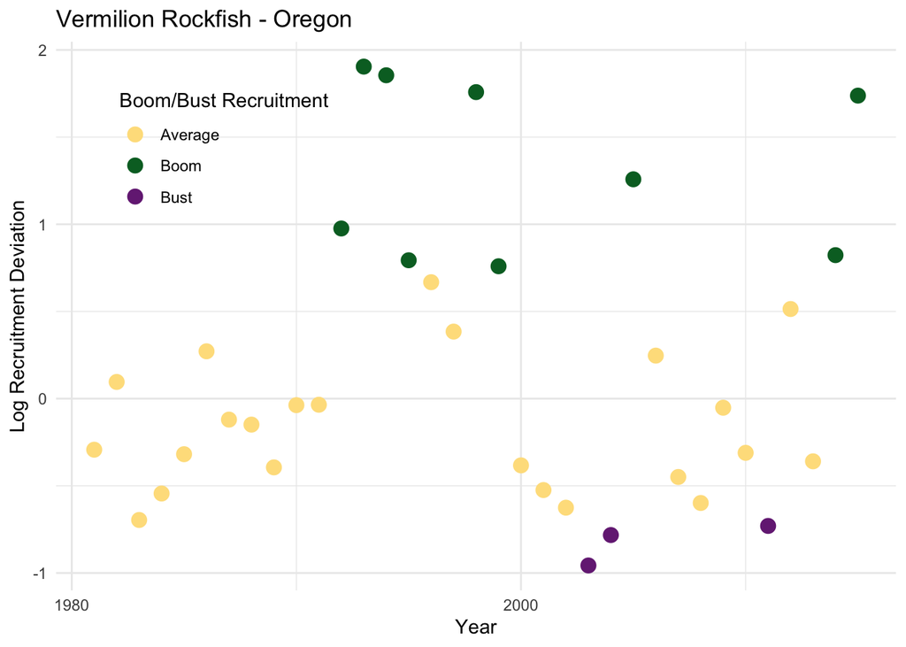

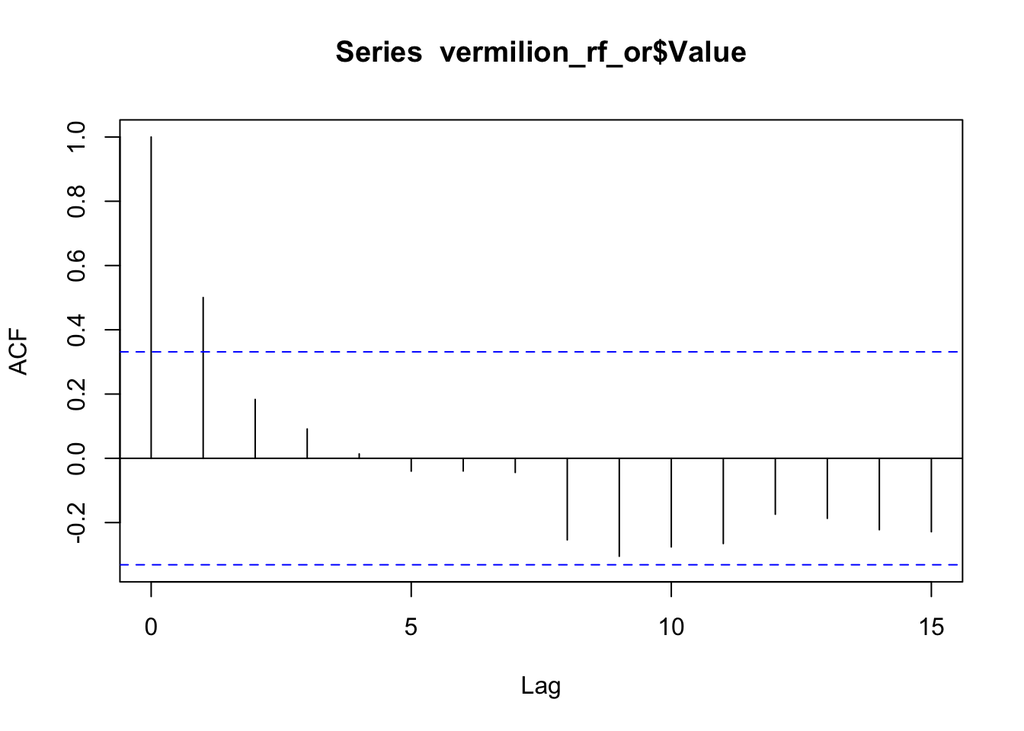

### Vermilion Rockfish - Washington (2021 assessment)

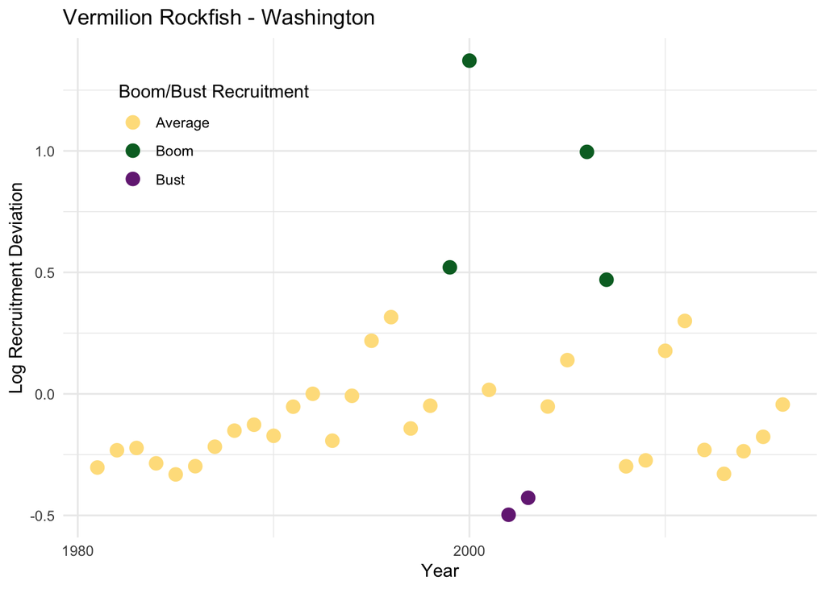

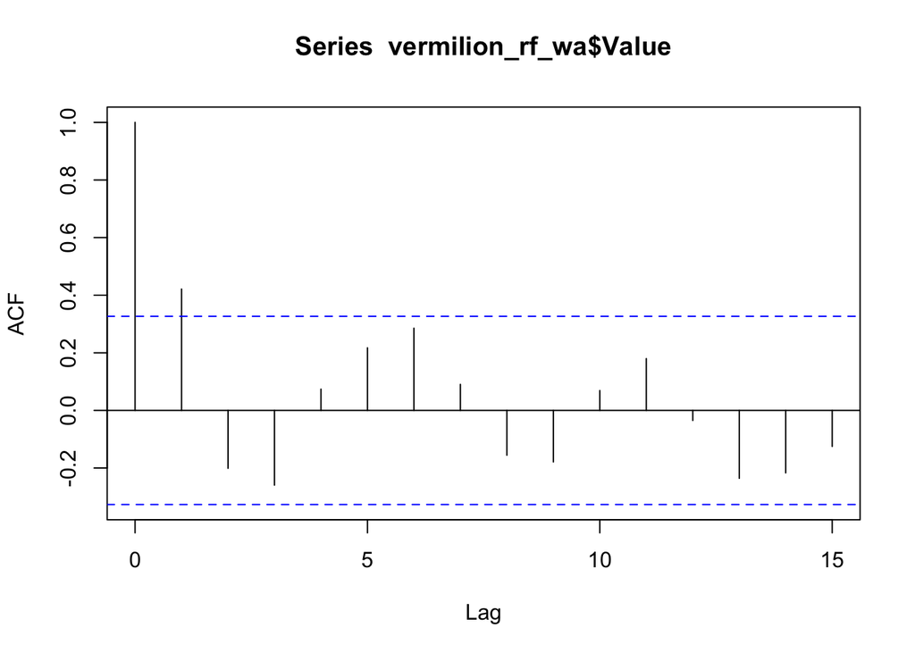

### Yelloweye Rockfish (2025 assessment)

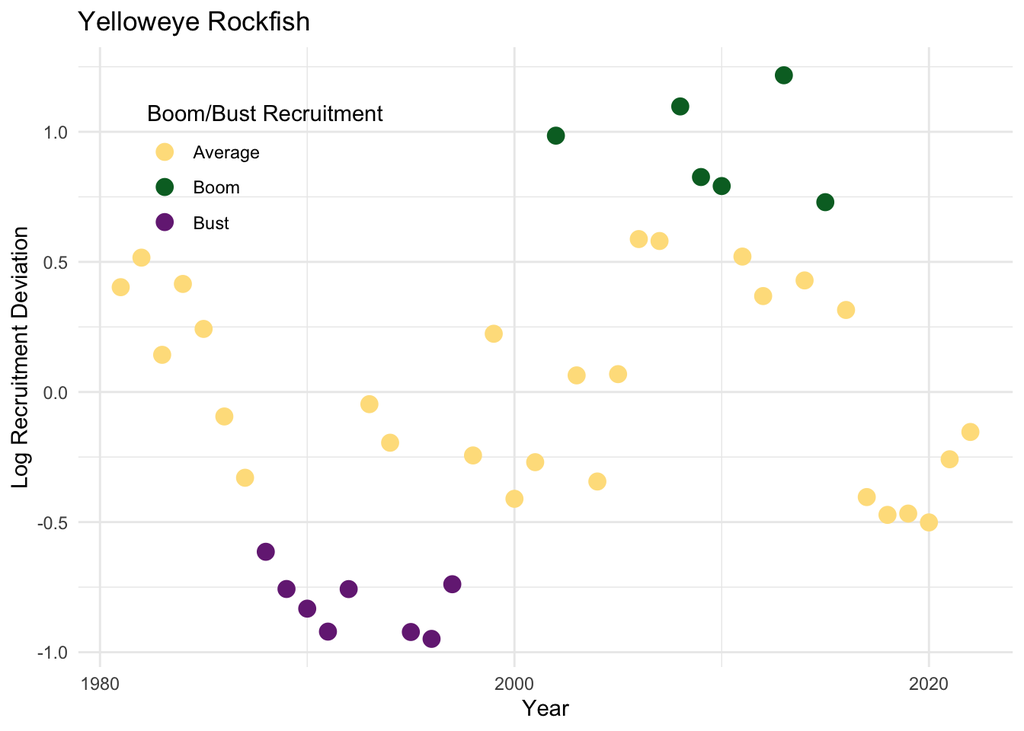

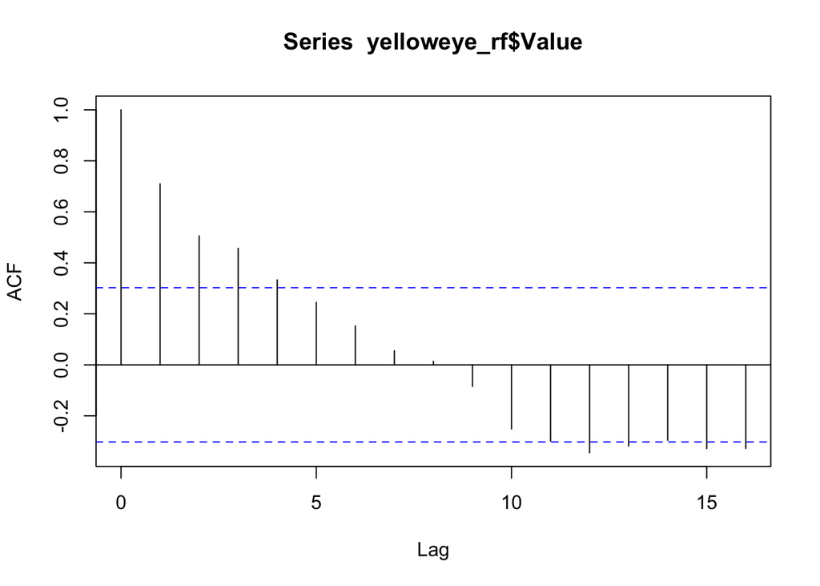

### Yellowtail Rockfish (2025 assessment)

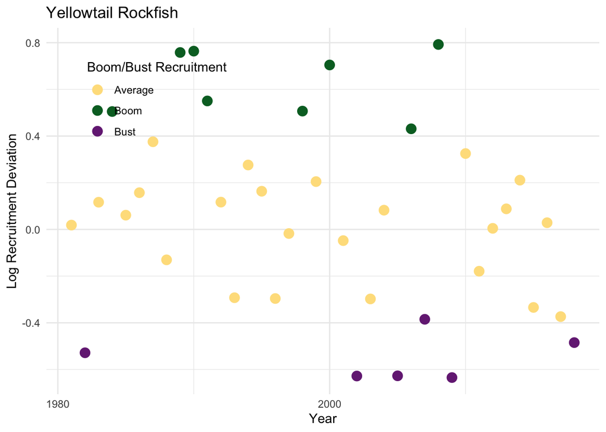

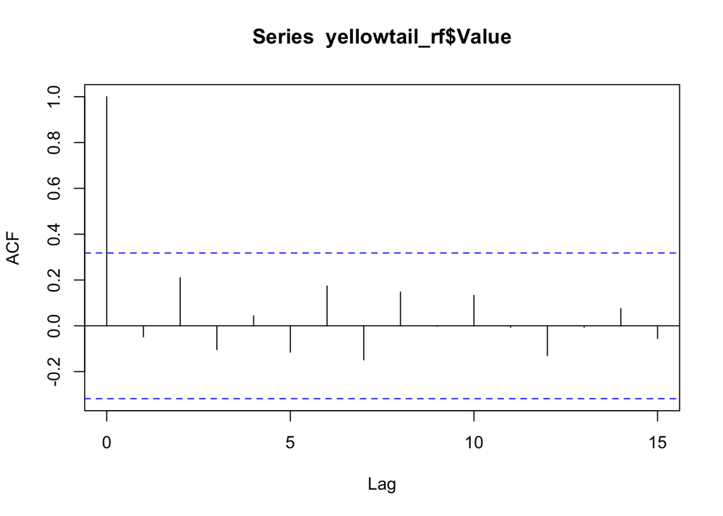

## Recruitment as a mixture

To explore whether the boom/bust distribution of recruitment deviations might be better represented as a mixture, a two distribution mixture mdoel was fit to the recruitment deviations for each stock. Additionally, Hartigan’s dip test was used to test if each distribution was significantly different from a unimodal distribution (spoiler alert, it was not for any stock).

p-values for Hartigan’s dip test, where a significant p-value indicates a significantly non-unimodal distribution.

| stock_name | dip.test.p.value |
| --- | --- |
| Black Rockfish - Northern CA | 0.134 |
| Black Rockfish - Central CA | 0.965 |
| Black Rockfish - Oregon | 0.993 |
| Black Rockfish - Washington | 0.815 |
| Canary Rockfish | 0.962 |
| Copper Rockfish - CA, North of Point Conception | 0.905 |
| Copper Rockfish - CA, South of Point Conception | 0.740 |
| Dover Sole | 0.304 |
| Lingcod - North of 40°10’N | 0.626 |
| Lingcod - South of 40°10’N | 0.991 |
| Petrale Sole | 0.551 |
| Quillback Rockfish | 0.991 |
| Rex Sole | 0.944 |
| Rougheye/Blackspotted Rockfish | 0.990 |
| Sablefish | 0.624 |
| Vermilion & Sunset Rockfish - Southern CA | 0.743 |
| Vermilion & Sunset Rockfish - Northern CA | 0.772 |
| Vermilion Rockfish - Oregon | 0.896 |
| Vermilion Rockfish - Washington | 0.714 |
| Yelloweye Rockfish | 0.934 |
| Yellowtail Rockfish | 0.679 |

## Recruitment Histograms + mixtures

### Black Rockfish - Northern CA (2023 assessment)

```
## number of iterations= 315
```

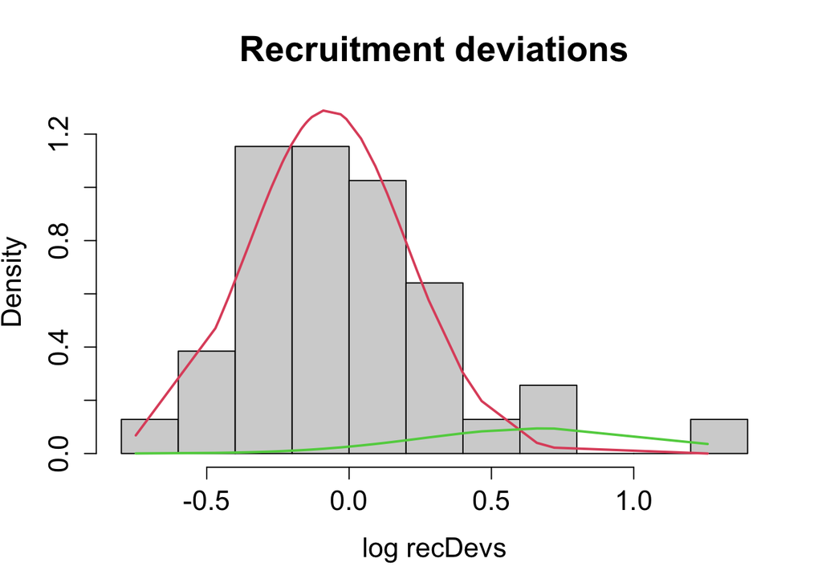

### Black Rockfish - Central CA (2023 assessment)

```
## One of the variances is going to zero;  trying new starting values.
## number of iterations= 36
```

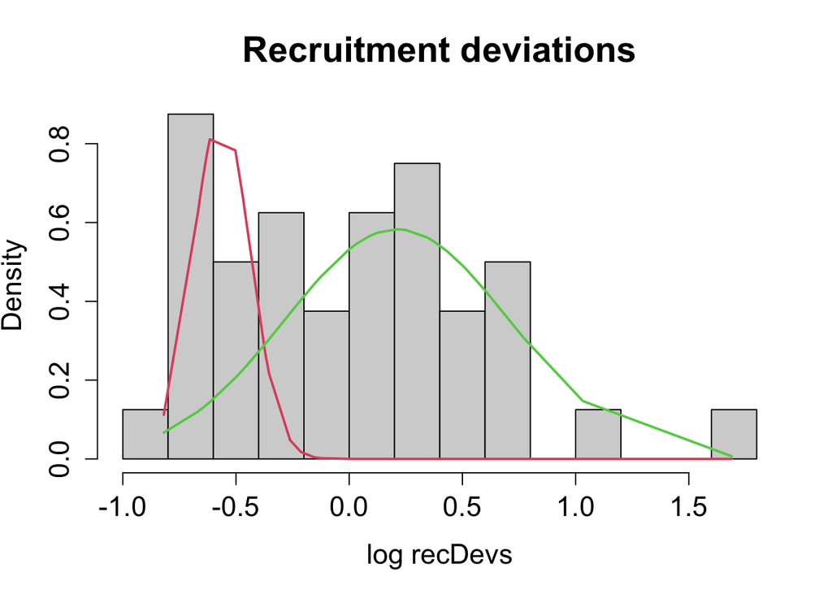

### Black Rockfish - Oregon (2023 assessment)

```
## number of iterations= 102
```

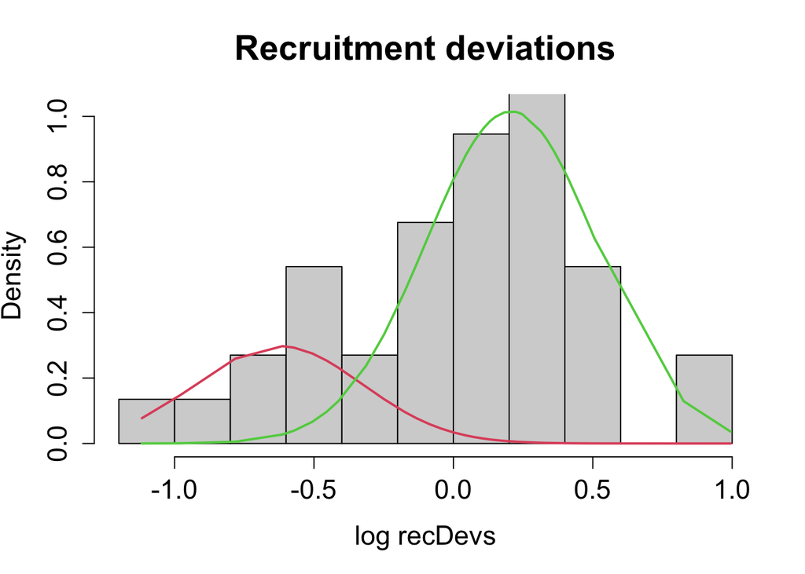

### Black Rockfish - Washington (2023 assessment)

```
## One of the variances is going to zero;  trying new starting values.
## WARNING! NOT CONVERGENT!
## number of iterations= 1000
```

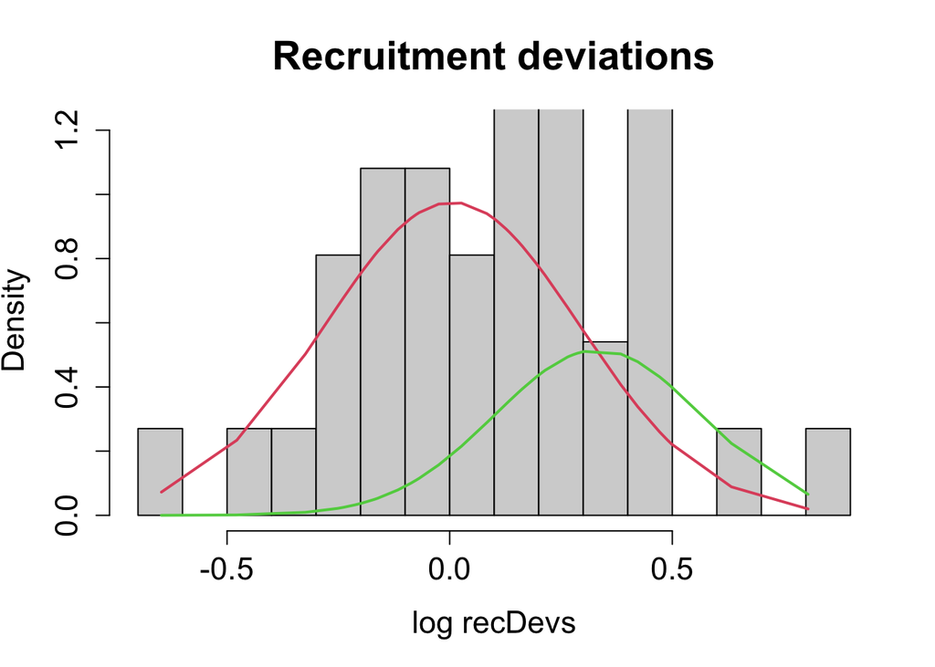

### Canary Rockfish (2023 assessment)

```
## number of iterations= 101
```

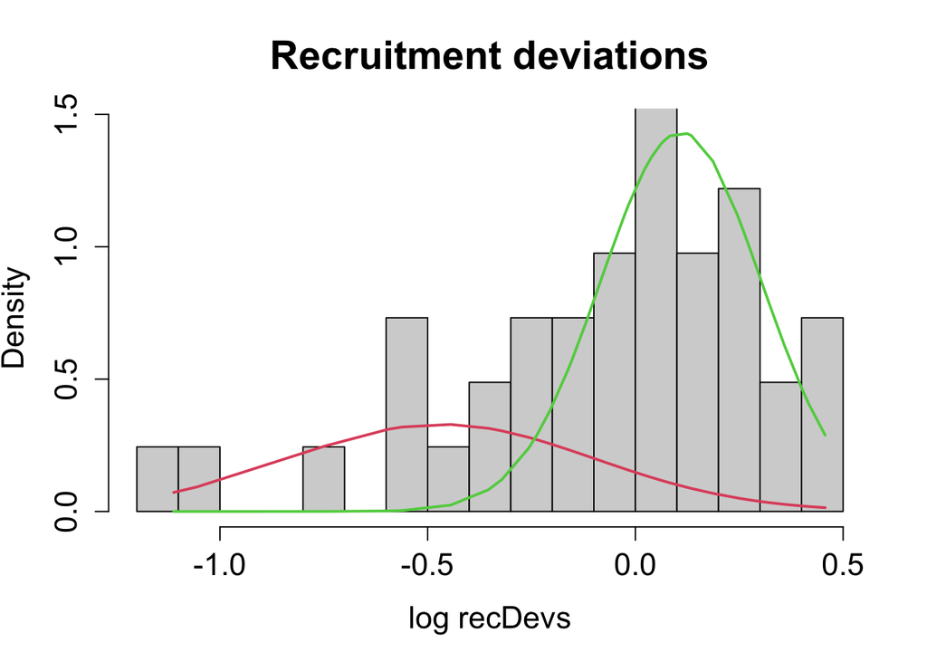

### Copper Rockfish - CA, North of Point Conception (2023 assessment)

```
## number of iterations= 65
```

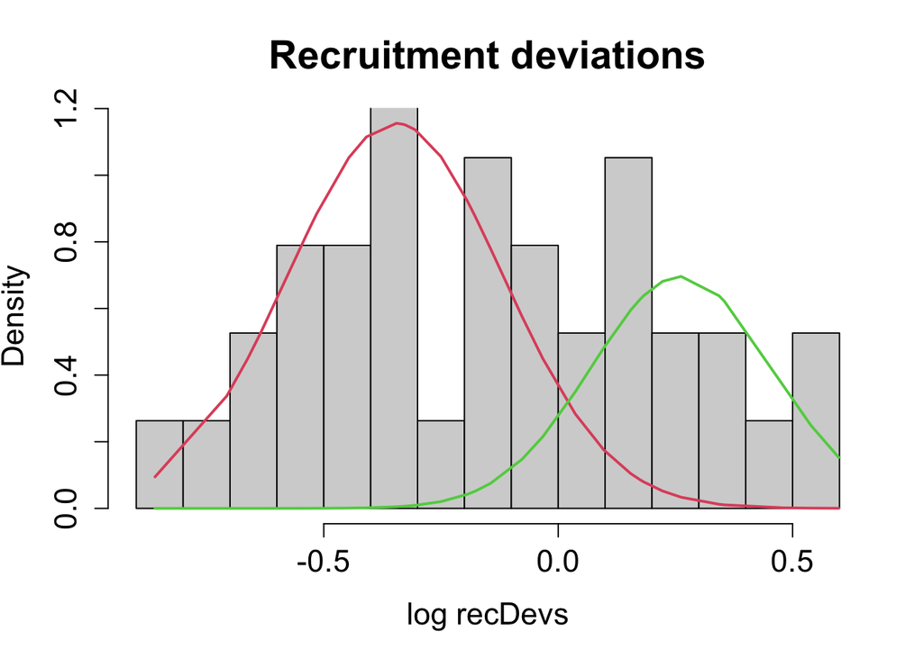

### Copper Rockfish - CA, South of Point Conception (2023 assessment)

```
## number of iterations= 95
```

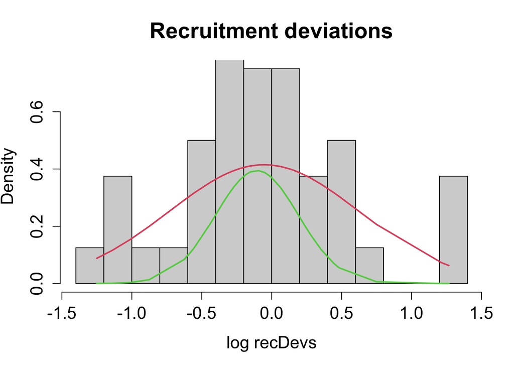

### Dover Sole (2021 assessment)

```
## number of iterations= 404
```

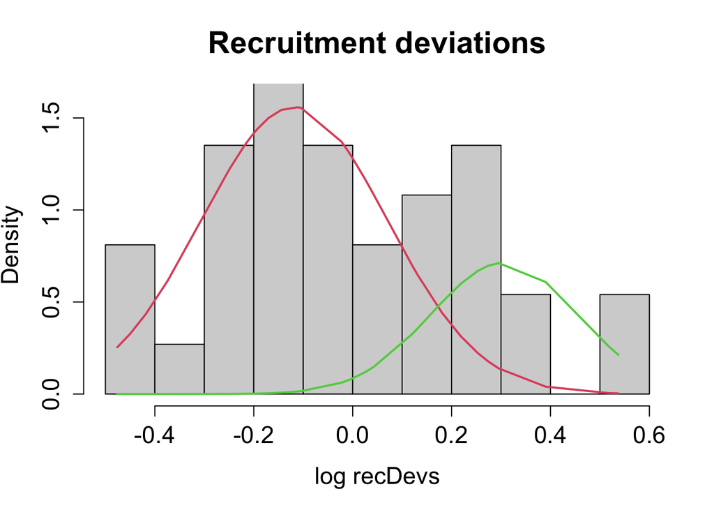

### Lingcod - North of 40°10’N (2021 assessment)

```
## number of iterations= 23
```

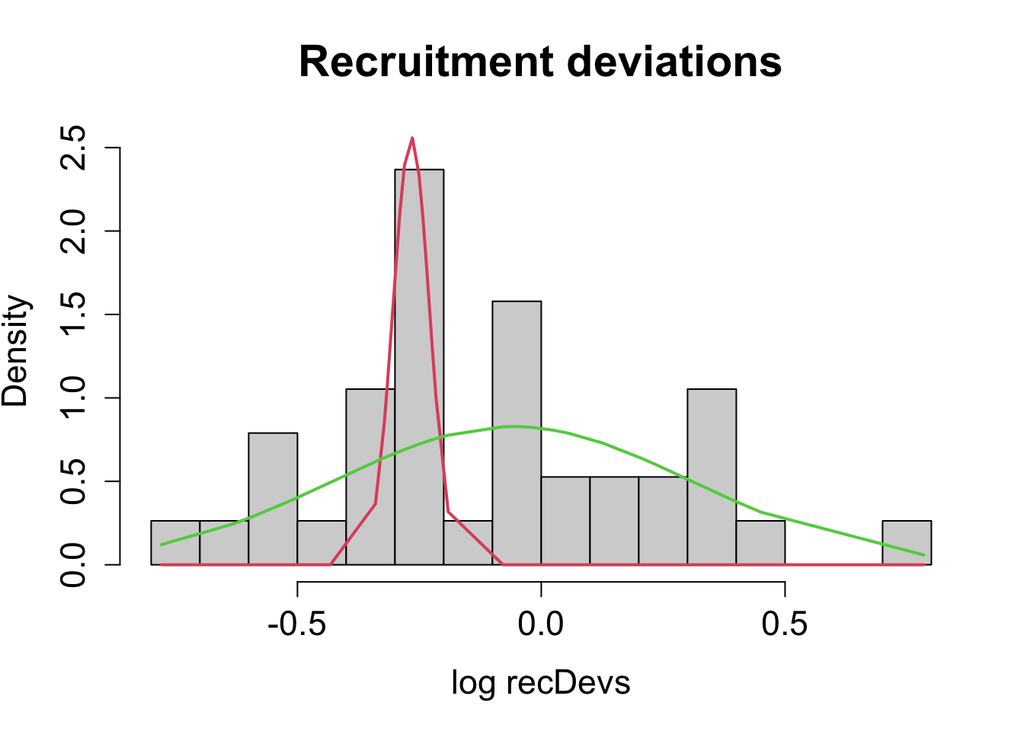

### Lingcod - South of 40°10’N (2021 assessment)

A mixture model could not be fit to this distribution.

### Petrale Sole (2023 assessment)

```
## number of iterations= 88
```

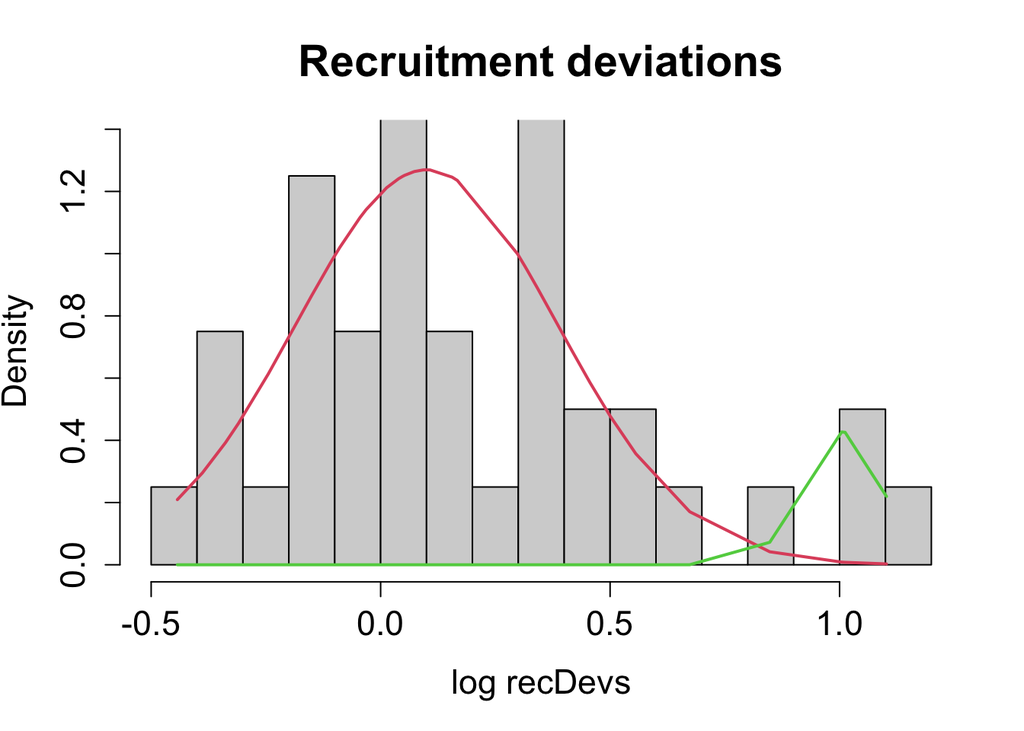

### Quillback Rockfish - California (2025 assessment)

```
## number of iterations= 95
```

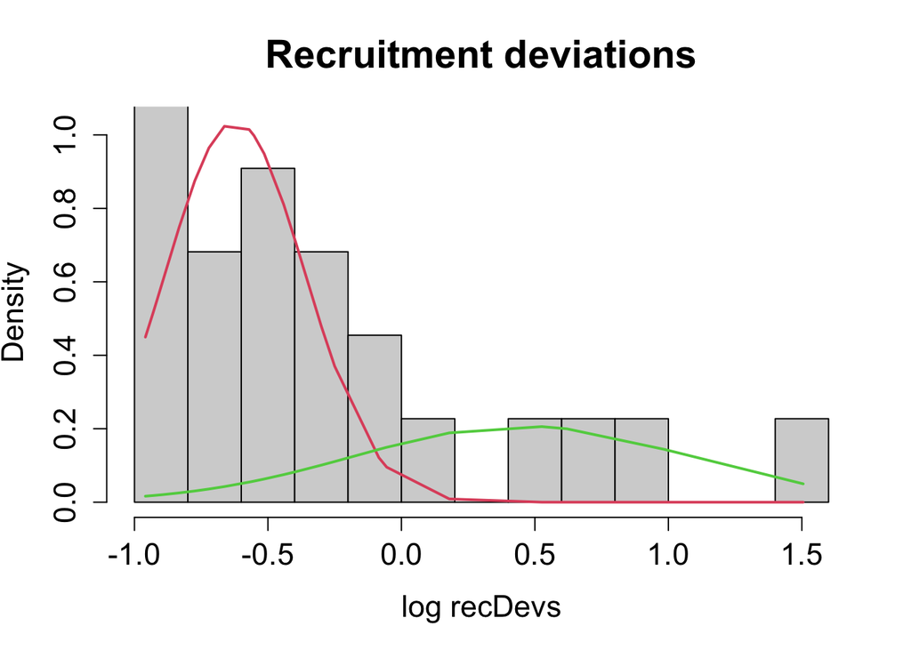

### Rex Sole (2023 assessment)

```
## number of iterations= 210
```

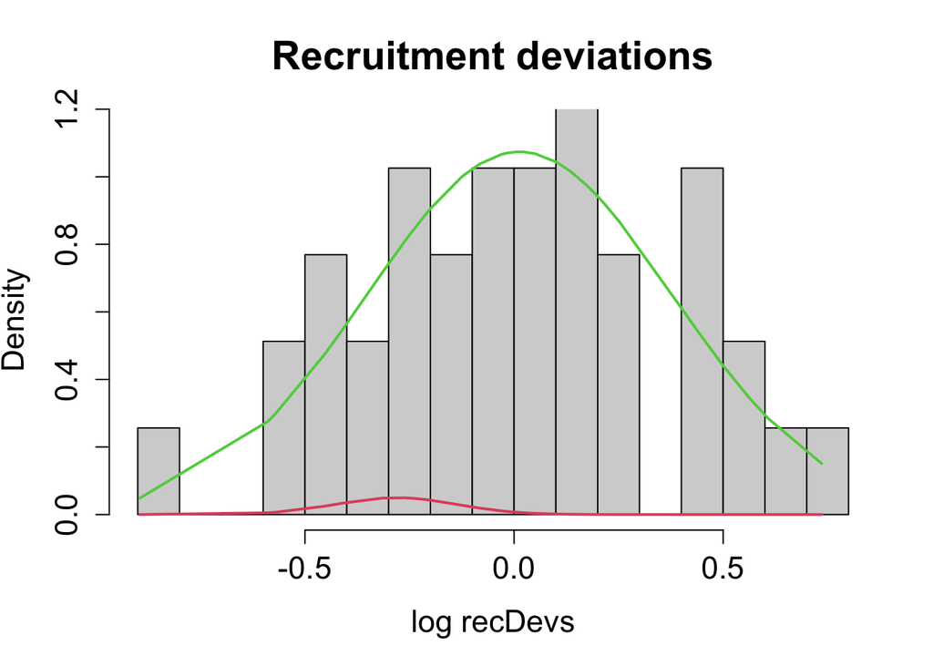

### Rougheye/Blackspotted Rockfish (2025 assessment)

```
## number of iterations= 35
```

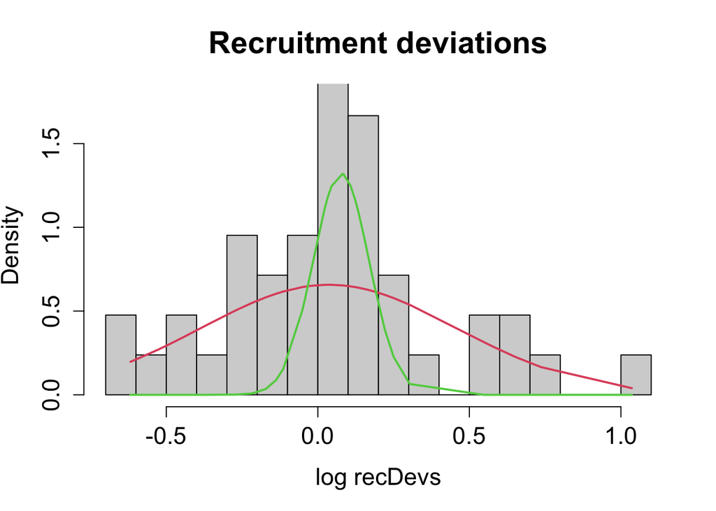

### Sablefish (2025 assessment)

```
## number of iterations= 450
```

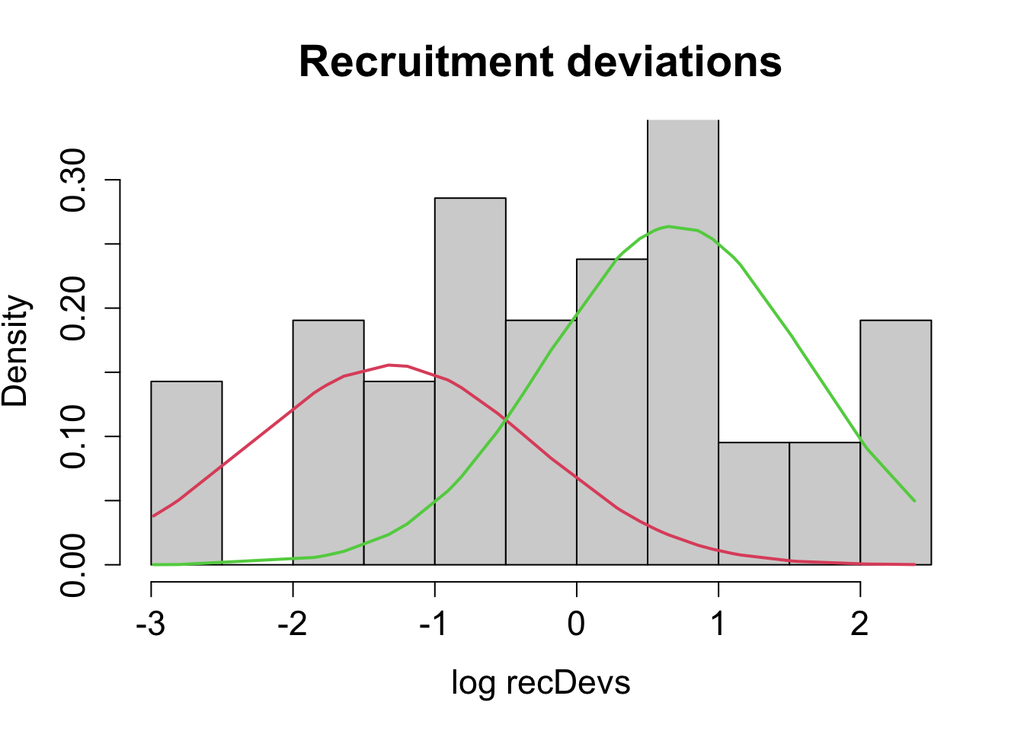

### Vermilion & Sunset Rockfish - Southern CA (2021 assessment)

```
## number of iterations= 56
```

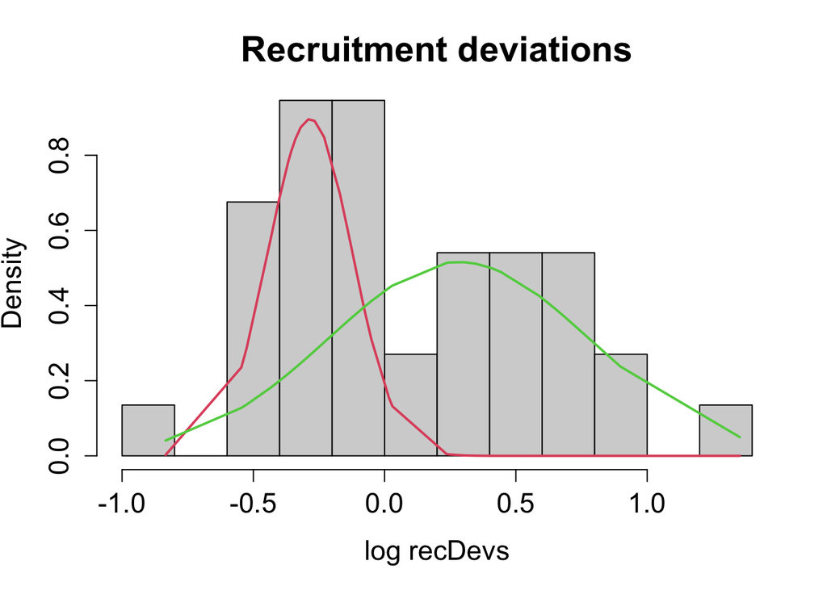

### Vermilion & Sunset Rockfish - Northern CA (2021 assessment)

```
## number of iterations= 12
```

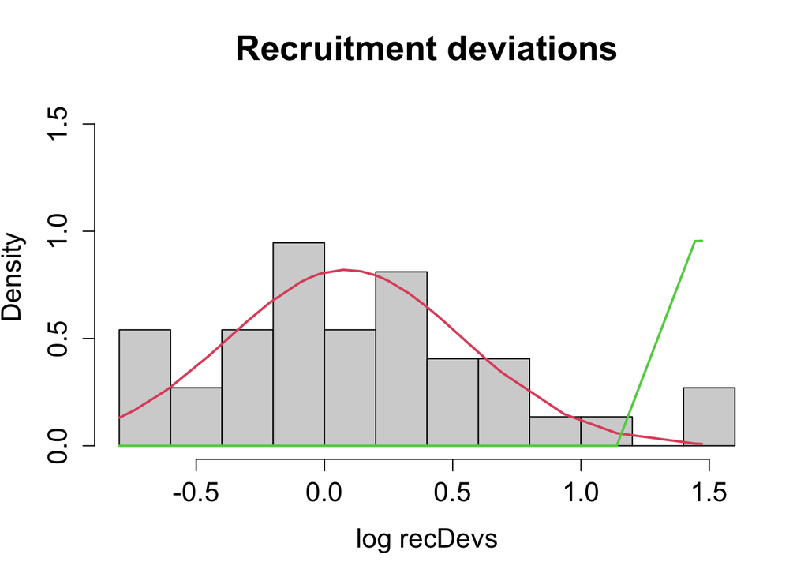

### Vermilion Rockfish - Oregon (2021 assessment)

```
## number of iterations= 53
```

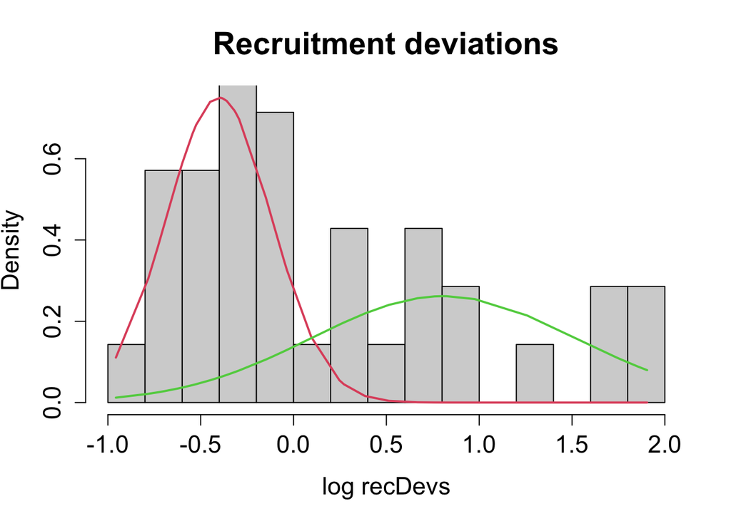

### Vermilion Rockfish - Washington (2021 assessment)

```
## number of iterations= 34
```

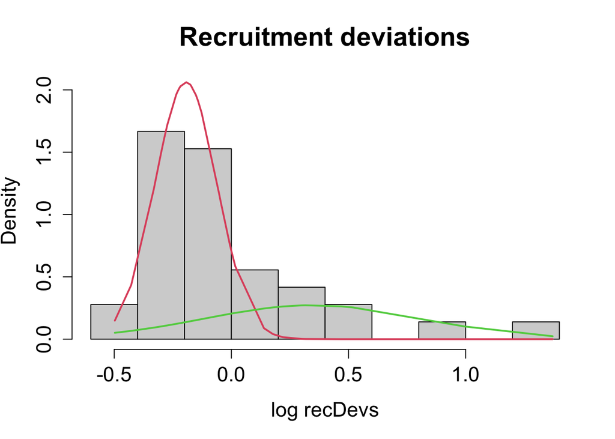

### Yelloweye Rockfish (2025 assessment)

```
## number of iterations= 58
```

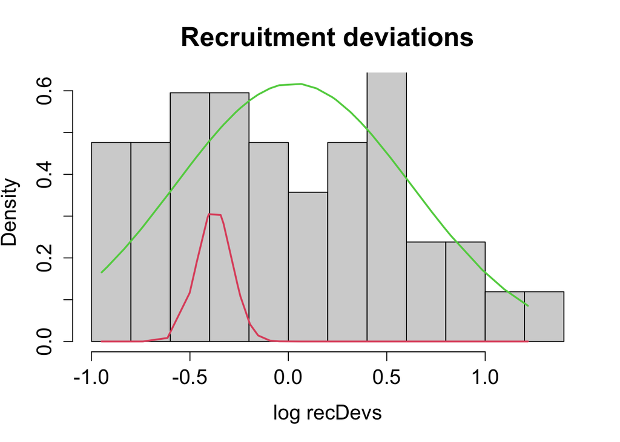

### Yellowtail Rockfish (2025 assessment)

```
## number of iterations= 73
```

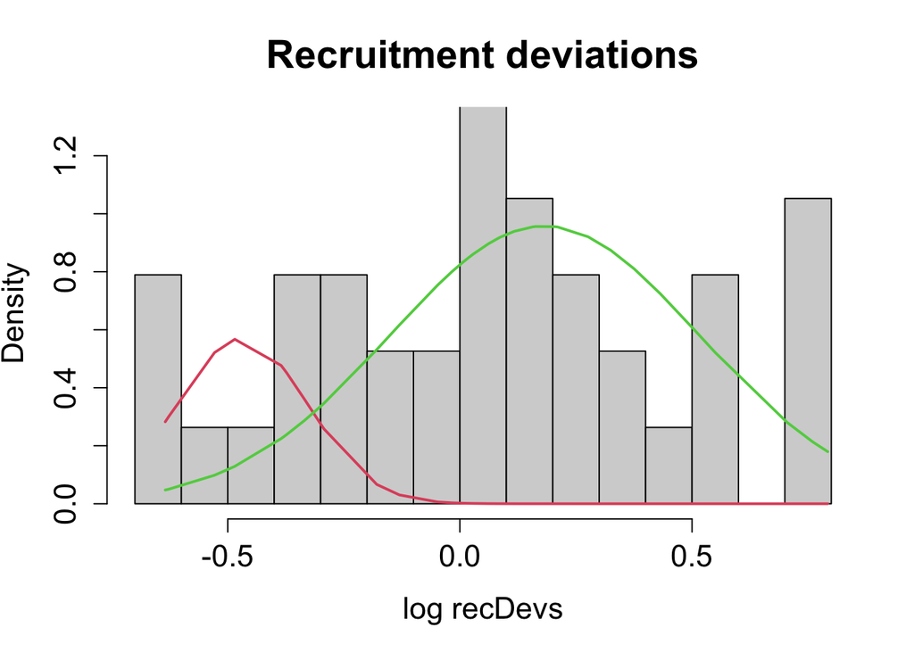